# R introduction and visualization

# Data frame manipulation

We already learned how to select rows and columns of a data frame, which is a large part of working with data. Let us now turn to some other useful data frame manipulations. Often we wish to arrange our data frame according to the values of some of our columns. For that, we can use the combination of selecting rows based on indexes and the function `order()`, which returns a permutation.

```r
claim_data <- read.csv("./data/insurance01.csv")
head(claim_data)
```

```
##   age    sex    bmi children smoker    region   charges
## 1  19 female 27.900        0    yes southwest 16884.924
## 2  18   male 33.770        1     no southeast  1725.552
## 3  28   male 33.000        3     no southeast  4449.462
## 4  33   male 22.705        0     no northwest 21984.471
## 5  32   male 28.880        0     no northwest  3866.855
## 6  31 female 25.740        0     no southeast  3756.622
```

```r
head(claim_data[order(claim_data$age), ])
```

```
##    age    sex    bmi children smoker    region   charges
## 2   18   male 33.770        1     no southeast  1725.552
## 23  18   male 34.100        0     no southeast  1137.011
## 32  18 female 26.315        0     no northeast  2198.190
## 47  18 female 38.665        2     no northeast  3393.356
## 51  18 female 35.625        0     no northeast  2211.131
## 58  18   male 31.680        2    yes southeast 34303.167
```

```r
head(claim_data[order(claim_data$age, claim_data$charges), ])
```

```
##      age  sex   bmi children smoker    region  charges
## 941   18 male 23.21        0     no southeast 1121.874
## 809   18 male 30.14        0     no southeast 1131.507
## 1245  18 male 33.33        0     no southeast 1135.941
## 664   18 male 33.66        0     no southeast 1136.399
## 23    18 male 34.10        0     no southeast 1137.011
## 195   18 male 34.43        0     no southeast 1137.470
```

To add new columns to the data frame, we can define the new column with the dollar sign, and assign into it the values. For example, let us add charges per person to our data frame.

```r
claim_data$charges_per_person <- claim_data$charges / (claim_data$children + 1)
head(claim_data)
```

```
##   age    sex    bmi children smoker    region   charges charges_per_person
## 1  19 female 27.900        0    yes southwest 16884.924         16884.9240
## 2  18   male 33.770        1     no southeast  1725.552           862.7762
## 3  28   male 33.000        3     no southeast  4449.462          1112.3655
## 4  33   male 22.705        0     no northwest 21984.471         21984.4706
## 5  32   male 28.880        0     no northwest  3866.855          3866.8552
## 6  31 female 25.740        0     no southeast  3756.622          3756.6216
```

Of course we can also use our own functions to create new variables. Let us create a new variable which will classify persons based on their BMI according to the standard BMI classification.

```r
classify_bmi <- function (bmi) {
  bmi_classes <- rep("underweight", times = length(bmi))
  bmi_classes[bmi >= 18.5 & bmi < 25] <- "normal"
  bmi_classes[bmi >= 25]              <- "overweight"
  bmi_classes <- factor(bmi_classes, levels = c("underweight",
                                                "normal",
                                                "overweight"),
                        ordered = TRUE)
  return(bmi_classes)
}
claim_data$bmi_class <- classify_bmi(claim_data$bmi)
head(claim_data)
```

```
##   age    sex    bmi children smoker    region   charges charges_per_person
## 1  19 female 27.900        0    yes southwest 16884.924         16884.9240
## 2  18   male 33.770        1     no southeast  1725.552           862.7762
## 3  28   male 33.000        3     no southeast  4449.462          1112.3655
## 4  33   male 22.705        0     no northwest 21984.471         21984.4706
## 5  32   male 28.880        0     no northwest  3866.855          3866.8552
## 6  31 female 25.740        0     no southeast  3756.622          3756.6216
##    bmi_class
## 1 overweight
## 2 overweight
## 3 overweight
## 4     normal
## 5 overweight
## 6 overweight
```

Two very useful function for extending data frames are `cbind()` and `rbind()`, which bind data frames according to columns and rows respectively. With `rbind()` we need to make sure that both data frames have the same column names.

```r
cbind_data <- cbind(claim_data[ ,c("age", "sex")], claim_data[ ,c("charges", "charges_per_person")])
head(cbind_data)
```

```
##   age    sex   charges charges_per_person
## 1  19 female 16884.924         16884.9240
## 2  18   male  1725.552           862.7762
## 3  28   male  4449.462          1112.3655
## 4  33   male 21984.471         21984.4706
## 5  32   male  3866.855          3866.8552
## 6  31 female  3756.622          3756.6216
```

```r
rbind_data <- rbind(claim_data[1:2, ], claim_data[claim_data$age == "20", ])
head(rbind_data)
```

```
##     age    sex    bmi children smoker    region   charges charges_per_person
## 1    19 female 27.900        0    yes southwest 16884.924         16884.9240
## 2    18   male 33.770        1     no southeast  1725.552           862.7762
## 65   20 female 22.420        0    yes northwest 14711.744         14711.7438
## 106  20   male 28.025        1    yes northwest 17560.380          8780.1899
## 123  20 female 28.975        0     no northwest  2257.475          2257.4752
## 135  20 female 28.785        0     no northeast  2457.211          2457.2112
##      bmi_class
## 1   overweight
## 2   overweight
## 65      normal
## 106 overweight
## 123 overweight
## 135 overweight
```

If we want some quick data analysis, we usually use some summary statistics. To get a meaningful analysis, we calculate those statistics depending on some variables. For example let us create a quick analysis on how smoking and bmi affect medical charges. We will do that by aggregating the charges depending on those two variables.

```r
claim_data2    <- claim_data
agg_claim_data <- aggregate(claim_data$charges, by = list("smoker" = claim_data$smoker, "bmi" = claim_data$bmi_class), FUN = mean)
agg_claim_data
```

```
##   smoker         bmi         x
## 1     no underweight  5532.992
## 2    yes underweight 18809.825
## 3     no      normal  7685.656
## 4    yes      normal 19942.224
## 5     no  overweight  8633.955
## 6    yes  overweight 35116.910
```

All of the above can be simplified using the **dplyr** package, which is out of scope for this workshop.

# Long and wide data formats

Usually we encounter data in a wide format. A wide format of data is a format where each row represents an object, some columns represent identifiers of this object, and several columns contain measurements associated with this object. On the other hand, in a long format each row represents a measurement. In other words, the columns that contain object identifiers remain unchanged, but we get a new row for each of the measured values. The long format is usually easier to process, while the wide format is easier to comprehend. Also several R functions (for example `ggplot`) require a long data format.

The functions for conversion between the formats in **tidyr** are `gather` (wide to long) and `spread` (long to wide). Let us look how to use them on a stock market data (acquired from the R package **datasets**). Here we have the daily closing prices of four major European stock indices between the years 1991 and 1998. Each row represents an object – the day of the closing prices. Then we have four measurements (prices). This data frame is therefore in a wide format. Let us convert it to a long format, and then back to wide, to see how to use `gather` and `spread`.

```r
library(tidyr)
stock_df <- readRDS("./data/stocks.rds")
df_long  <- gather(stock_df, key = "stock", value = "price", -time)
head(df_long)
```

```
## # A tibble: 6 x 3
##    time stock price
##   <dbl> <chr> <dbl>
## 1 1991. X.DAX 1629.
## 2 1992. X.DAX 1614.
## 3 1992. X.DAX 1607.
## 4 1992. X.DAX 1621.
## 5 1992. X.DAX 1618.
## 6 1992. X.DAX 1611.
```

```r
df_wide  <- spread(df_long, key = "stock", value = "price")
head(df_wide)
```

```
## # A tibble: 6 x 5
##    time X.CAC X.DAX X.FTSE X.SMI
##   <dbl> <dbl> <dbl>  <dbl> <dbl>
## 1 1991. 1773. 1629.  2444. 1678.
## 2 1992. 1750. 1614.  2460. 1688.
## 3 1992. 1718  1607.  2448. 1679.
## 4 1992. 1708. 1621.  2470. 1684.
## 5 1992. 1723. 1618.  2485. 1687.
## 6 1992. 1714. 1611.  2467. 1672.
```

# Visualization

Visualization is indispensible when working with data. It can help us to explain our findings better and more concisely than numbers or tables alone. On the other hand it can be abused to fit someone’s agenda, so we need to be careful when interpreting someone else’s visualizations. In this chapter we will familiarize ourselves with visualization in R using the **ggplot2** package and also show a couple of examples how the author of the plots can deceive the potential public.

## ggplot2 package

The ggplot2 package is an extremely powerful tool for drawing all kinds of data visualizations. The ggplot2 package is build upon concepts described by Leland Wilkinson in his book Grammar of Graphics. Wilkinson defines data visualizations through seven layers:

1. Data – the actual variables to be plotted.
2. Aesthetics (aes) – the scales on which the data is mapped.
3. Geometries (geoms) – shapes that visually represent the data.
4. Facets – rows and columns for sub-plots.
5. Statistics – statistical models, functions and summaries.
6. Coordinates – the plotting space.
7. Themes – design elements, such as titles, labels, ticks, legends, etc.

We will see how we build data visualizations with ggplot2 by stacking these layers on top of eachother through practical examples.

### Stocks data

Let us start with our stocks data set. When plotting time-series, a line plot is the most suitable option. Let us first create a plot and then explain the components. We will plot a line plot with time on the x-axis and value of the stock on the y-axis for the DAX stock

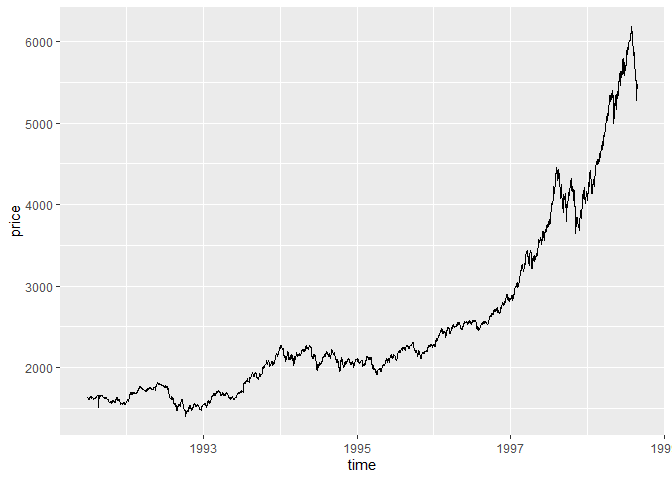

```r
library(ggplot2)
df_dax <- df_long[df_long$stock == "X.DAX", ]
ggplot(data = df_dax, aes(x = time, y = price)) +
  geom_line()
```

Code above executes the described steps. First, we tell ggplot that our data source will be `df_dax`, note here that plots expect data in the long format. The `aes()` function defines the aesthetic mapping, in the above example we simply map the `time` variable to the x-axis and the `price` variable to the y-axis. In ggplot2 chart types are defined through geometrics (geoms), for example `geom_line()` tells ggplot to draw a line chart. We can easily stack geoms together. Geoms that appear later in our code are drawn on top of previous geoms.

With plots like the one above it makes sense to show the absolute value, otherwise the plots can be deceiving. For example, let us look at a subset of the above and use the same plot.

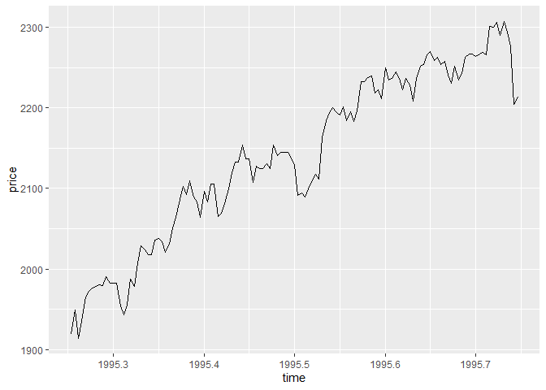

```r
df_sub <- df_dax[as.numeric(df_dax$time) > 1995.25 & as.numeric(df_dax$time) < 1995.75, ]
ggplot(data = df_sub, aes(x = time, y = price)) +
  geom_line()
```

Looks like a rather dramatic increase in the stock price. Now let us add the lower limit of the price.

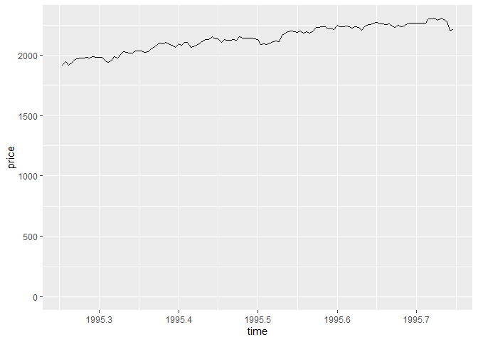

```r
df_sub <- df_dax[as.numeric(df_dax$time) > 1995.25 & as.numeric(df_dax$time) < 1995.75, ]
ggplot(data = df_sub, aes(x = time, y = price)) +
  geom_line() +
  coord_cartesian(ylim = c(0,2300))
```

Here we used `coord_cartesian` to manually scale the y-axis. We see that the increase is actually not that steep. Companies can use such tricks to deceive the customers or shareholders so watch out for deceiving visualizations, they are not uncommon.

So far we only plotted the prices of one stock. Let us compare the values of all stocks in our data set. The best way in this case, to directly compare the prices is to plot them on the same plot, and use different colours to distinguish between them. Luckily, this is very easy with ggplot, as we only need to add another aesthetic mapping. We will map the variable `stock` to colour.

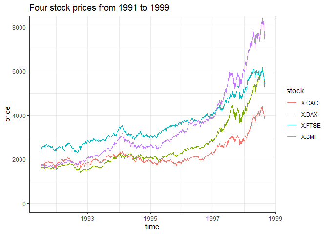

```r
ggplot(data = df_long, aes(x = time, y = price, color = stock)) +
  geom_line() +
  coord_cartesian(ylim = c(0, 8100)) +
  ggtitle("Four stock prices from 1991 to 1999") +
  theme_bw()
```

Additionally, we added a plot title, and used a black-and-white theme, instead of the default grey. There are several arguments that can be passed to `theme` to generate output that you desire. `theme_bw` is a special case that provides us with the above output. See `?theme` and `?theme_bw` for more information.

### Insurance claim data

Now let us try to create some meaningful visualizations on the insurance claim data set. Here we are not that interested in the relationship between two variables (as above between time and price), but rather the in the distribution of the charges, depending on some classes, mainly if a person is a smoker or not and what is their BMI class. Useful plots for visualizing the distributions are **barcharts**, **histograms**, **boxplots** and **density plots**. Let us first visualize our aggregate table using a barchart.

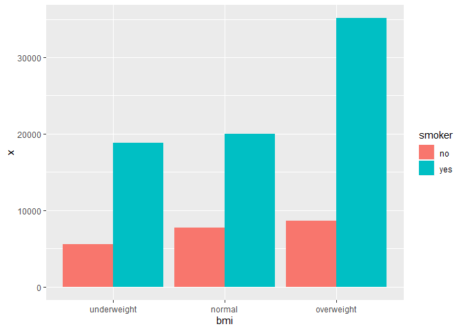

```r
ggplot(data = agg_claim_data, aes(x = bmi, y = x, fill = smoker)) +
  geom_col(position = "dodge")
```

We used `geom_col` to generate the bars, see `?geom_col` for additional information. The `fill` aesthetic is more appropriate here than color, since color would only color the edges, while fill fills the whole area. Additionally, we used `position = "dodge"`, otherwise the bars would be stacked.

The plot looks good. However we can approach this another way. Instead of using colors, we can divide the graph into facets, depending on some variable.

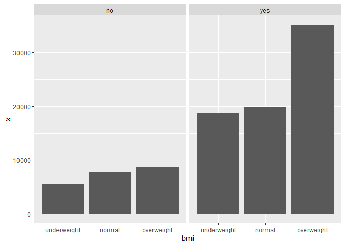

```r
ggplot(data = agg_claim_data, aes(x = bmi, y = x)) +
  geom_col(position = "dodge") +
  facet_wrap(~ smoker)
```

We can also use facets with more variables, for example let us add sex to our plot. Additionally, we could have different scales in each facet, using the argument `scales = "free"`, however that would not make much sense in our case.

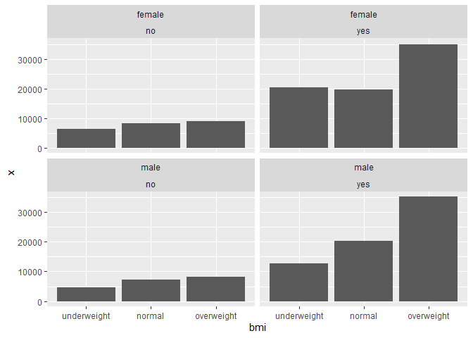

```r
agg_claim_data2 <- aggregate(claim_data2$charges, by = list("smoker" = claim_data2$smoker, "bmi" = claim_data2$bmi_class, "sex" = claim_data2$sex), FUN = mean)
ggplot(data = agg_claim_data2, aes(x = bmi, y = x)) +
  geom_col() +
  facet_wrap(sex ~ smoker)
```

Barplots only show point estimates and give us no information about the variability of the charges – this is a major drawback. Additionally, this makes it very easy to “cheat” with them. Obviously there is an increasing trend in the charges that rises with BMI. However, for non-smokers it is not that drastic. But if we wanted someone to believe it is, we could have done something like this.

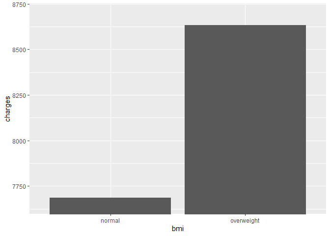

```r
tmp_data <- claim_data2[claim_data2$smoker == "no" & claim_data2$bmi_class %in% c("normal", "overweight"), ]
agg_tmp_data <- aggregate(tmp_data$charges, by = list("bmi" = tmp_data$bmi_class), FUN = mean)
ggplot(data = agg_tmp_data, aes(x = bmi, y = x)) +
  geom_col() +
  coord_cartesian(ylim = c(7650, 8700)) +
  labs(y = "charges")
```

At first glance the difference is huge, while we already know that it is rather small. But someone who is not paying attention to detail might not notice this, and would believe our story. The only thing we did is change the scale, similar to the example with stocks data. Additionally, this is the first time we used the `labs` layer, which allows us to rename the labels.

So we argue that point statistics are not the best summary we can provide to our audience. A better alternative would be to provide some kind of uncertainty estimate, or better yet, visualize the whole distribution. A useful plot for such visualization is the boxplot.

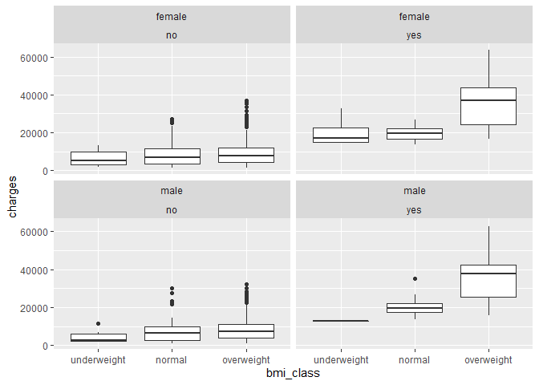

```r
ggplot(data = claim_data2, aes(x = bmi_class, y = charges)) +
  geom_boxplot() +
  facet_wrap(sex ~ smoker)
```

Additionally, we can use histograms or density plots, to even better see the distributions. These are not as concise as a boxplot, but arguably provide us with more information.

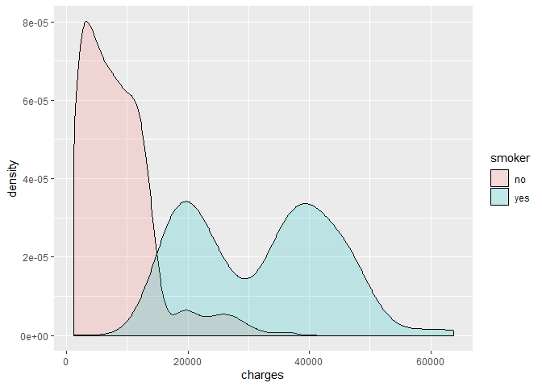

```r
ggplot(data = claim_data2, aes(x = charges, fill = smoker)) +
  geom_density(alpha = 0.2)
```

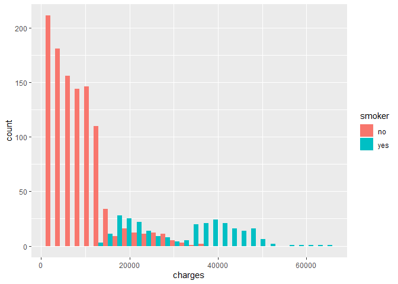

```r
ggplot(data = claim_data2, aes(x = charges, fill = smoker)) +
  geom_histogram(position = "dodge")
```

### Movies

```r
movies_df <- read.csv2("./data/movies.csv")
head(movies_df)
```

```
##   X                      title year length   budget rating votes
## 1 1                    $windle 2002     93       NA    5.3   200
## 2 2               'A' gai waak 1983    106       NA    7.1  1259
## 3 3      'A' gai waak juk jaap 1987    101       NA    7.2   614
## 4 4                    'R Xmas 2001     83       NA    4.9   288
## 5 5         'Til There Was You 1997    113 23000000    4.8   799
## 6 6 10 Things I Hate About You 1999     97 16000000    6.7 19095
```

An interesting insight in this data set would be, whether a higher budget yields a better rating. To see a connection between two numerical variables, a useful plot is a **scatterplot**.

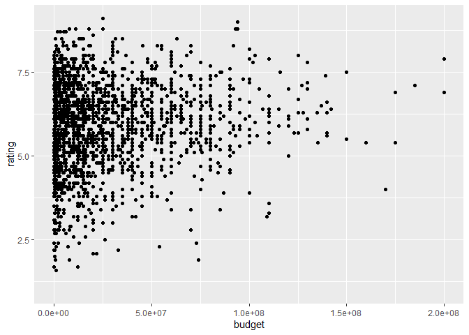

```r
ggplot(data = movies_df, aes(x = budget, y = rating)) +
  geom_point()
```

This plot looks rather messy. The biggest problem is the overlapping points which prevent us to properly see the density of points. We will change the transparency of the points to get a better feel for the density. Additionally, let us add more ticks on the x-axis and add a title.

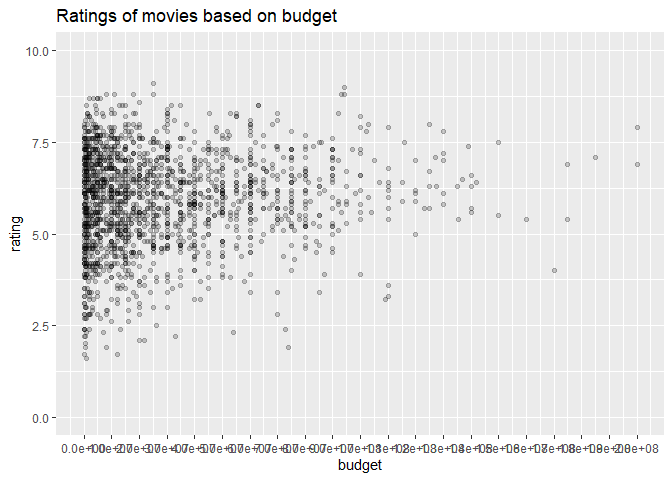

```r
ggplot(data = movies_df, aes(x = budget, y = rating)) +
  geom_point(alpha = 0.2) +
  ggtitle("Ratings of movies based on budget") +
  scale_x_continuous(breaks = c(seq(from = 0, to = 200000000, by = 10000000))) +
  coord_cartesian(ylim = c(0, 10))
```

OK, we can better see the density now. However the ticks are overlapping. We will correct this by rotating the ticks with `theme`. Additionally, in such situation it makes sense to get some visual summary of the trend in the plots. The simplest way to do this in a scatterplot is by using `geom_smooth()`. For the method we will pick a linear model, however `geom_smooth()` allows us to use more flexible models, such as locally estimated scatterplot smoothing (loess).

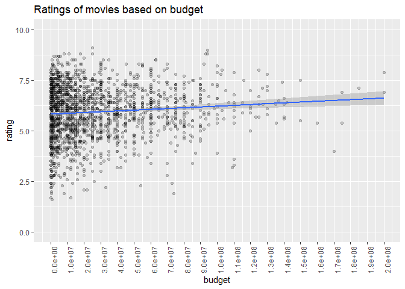

```r
ggplot(data = movies_df, aes(x = budget, y = rating)) +
  geom_point(alpha = 0.2) +
  ggtitle("Ratings of movies based on budget") +
  scale_x_continuous(breaks = c(seq(from = 0, to = 200000000, by = 10000000))) +
  coord_cartesian(ylim = c(0, 10)) +
  theme(axis.text.x = element_text(angle = 90)) +
  geom_smooth(method = "lm")
```

# Other tips and further reading

- To dynamically set the working directory in R Studio to the parent folder of a R script use `setwd(dirname(rstudioapi::getSourceEditorContext()$path))`.
- To avoid slow R loops use the apply family of functions. See `?apply` and `?lapply`.
- Use `getAnywhere(function_name)` to get the source code of any function.
- Getting started with R Studio: https://www.youtube.com/watch?v=lVKMsaWju8w
- Official R manuals: https://cran.r-project.org/manuals.html
- Cheatsheets: https://www.rstudio.com/resources/cheatsheets/
- Workshop on R, dplyr, ggplot2, and R Markdown: https://github.com/bstatcomp/Rworkshop